# Question 1

```python
import numpy as np
import pandas as pd
import seaborn as sns
import matplotlib.pyplot as plt
% matplotlib inline
```

```python
df = pd.read_csv('data/bank.csv')
df.head()
```

|  | CHK_ACCT | DURATION | HISTORY | NEW_CAR | USED_CAR | FURNITURE | RADIO/TV | EDUCATION | RETRAINING | AMOUNT | ... | AGE | OTHER_INSTALL | RENT | OWN_RES | NUM_CREDITS | JOB | NUM_DEPENDENTS | TELEPHONE | FOREIGN | RESPONSE |
| --- | --- | --- | --- | --- | --- | --- | --- | --- | --- | --- | --- | --- | --- | --- | --- | --- | --- | --- | --- | --- | --- |
| 0 | 0 | 6 | 4 | 0 | 0 | 0 | 1 | 0 | 0 | 1169 | ... | 67 | 0 | 0 | 1 | 2 | 2 | 1 | 1 | 0 | 1 |
| 1 | 1 | 48 | 2 | 0 | 0 | 0 | 1 | 0 | 0 | 5951 | ... | 22 | 0 | 0 | 1 | 1 | 2 | 1 | 0 | 0 | 0 |
| 2 | 3 | 12 | 4 | 0 | 0 | 0 | 0 | 1 | 0 | 2096 | ... | 49 | 0 | 0 | 1 | 1 | 1 | 2 | 0 | 0 | 1 |
| 3 | 0 | 42 | 2 | 0 | 0 | 1 | 0 | 0 | 0 | 7882 | ... | 45 | 0 | 0 | 0 | 1 | 2 | 2 | 0 | 0 | 1 |
| 4 | 0 | 24 | 3 | 1 | 0 | 0 | 0 | 0 | 0 | 4870 | ... | 53 | 0 | 0 | 0 | 2 | 2 | 2 | 0 | 0 | 0 |

5 rows × 31 columns

```python
df.describe()
```

|  | CHK_ACCT | DURATION | HISTORY | NEW_CAR | USED_CAR | FURNITURE | RADIO/TV | EDUCATION | RETRAINING | AMOUNT | ... | AGE | OTHER_INSTALL | RENT | OWN_RES | NUM_CREDITS | JOB | NUM_DEPENDENTS | TELEPHONE | FOREIGN | RESPONSE |
| --- | --- | --- | --- | --- | --- | --- | --- | --- | --- | --- | --- | --- | --- | --- | --- | --- | --- | --- | --- | --- | --- |
| count | 1000.000000 | 1000.000000 | 1000.00000 | 1000.000000 | 1000.000000 | 1000.000000 | 1000.000000 | 1000.000000 | 1000.000000 | 1000.000000 | ... | 1000.000000 | 1000.000000 | 1000.000000 | 1000.000000 | 1000.000000 | 1000.000000 | 1000.000000 | 1000.000000 | 1000.000000 | 1000.000000 |
| mean | 1.577000 | 20.903000 | 2.54500 | 0.234000 | 0.103000 | 0.181000 | 0.280000 | 0.050000 | 0.097000 | 3271.258000 | ... | 35.546000 | 0.186000 | 0.179000 | 0.713000 | 1.407000 | 1.904000 | 1.155000 | 0.404000 | 0.037000 | 0.700000 |
| std | 1.257638 | 12.058814 | 1.08312 | 0.423584 | 0.304111 | 0.385211 | 0.449224 | 0.218054 | 0.296106 | 2822.736876 | ... | 11.375469 | 0.389301 | 0.383544 | 0.452588 | 0.577654 | 0.653614 | 0.362086 | 0.490943 | 0.188856 | 0.458487 |
| min | 0.000000 | 4.000000 | 0.00000 | 0.000000 | 0.000000 | 0.000000 | 0.000000 | 0.000000 | 0.000000 | 250.000000 | ... | 19.000000 | 0.000000 | 0.000000 | 0.000000 | 1.000000 | 0.000000 | 1.000000 | 0.000000 | 0.000000 | 0.000000 |
| 25% | 0.000000 | 12.000000 | 2.00000 | 0.000000 | 0.000000 | 0.000000 | 0.000000 | 0.000000 | 0.000000 | 1365.500000 | ... | 27.000000 | 0.000000 | 0.000000 | 0.000000 | 1.000000 | 2.000000 | 1.000000 | 0.000000 | 0.000000 | 0.000000 |
| 50% | 1.000000 | 18.000000 | 2.00000 | 0.000000 | 0.000000 | 0.000000 | 0.000000 | 0.000000 | 0.000000 | 2319.500000 | ... | 33.000000 | 0.000000 | 0.000000 | 1.000000 | 1.000000 | 2.000000 | 1.000000 | 0.000000 | 0.000000 | 1.000000 |
| 75% | 3.000000 | 24.000000 | 4.00000 | 0.000000 | 0.000000 | 0.000000 | 1.000000 | 0.000000 | 0.000000 | 3972.250000 | ... | 42.000000 | 0.000000 | 0.000000 | 1.000000 | 2.000000 | 2.000000 | 1.000000 | 1.000000 | 0.000000 | 1.000000 |
| max | 3.000000 | 72.000000 | 4.00000 | 1.000000 | 1.000000 | 1.000000 | 1.000000 | 1.000000 | 1.000000 | 18424.000000 | ... | 75.000000 | 1.000000 | 1.000000 | 1.000000 | 4.000000 | 3.000000 | 2.000000 | 1.000000 | 1.000000 | 1.000000 |

8 rows × 31 columns

### Which columns would influence the response variable the most?

1: History.

The history column describes a persons credit history, and how well they have managed their loans and debt in the past, and this would be a good predictor of how likely someone might be to repay any future loans given out by the bank.

2: Employment

The employment column tells us how long someone has been employed, and the longer someone has been employed, the more likely it is that they make more money, thus it is more likely that they have the financial resources available to repay a new loan.

3: Job

The job column tells us what kind of job a person has, from low/unskilled labor to highly skilled labor, and this again ties in to employment, and if someone is working a low or unskilled job, they might not make as much money, and therefore might not be able to pay back the loan, and vice versa for those in higher skilled positions.

# Question 2

```python
# 2.A

df['CHK_ACCT'].mean()
```

```
1.577
```

```python
#2.B
df['DURATION'].max()
```

```
72
```

```python
df['DURATION'].min()
```

```
4
```

# Question 3

```python
df.groupby('RESPONSE').size()
```

```
RESPONSE
0    300
1    700
dtype: int64
```

##### We see that 70% of borrowers repayed the loans that they were given, and 30% did not repay.

# Question 4

```python
df.groupby(['HISTORY','RESPONSE']).size().unstack()
```

| RESPONSE HISTORY | 0 | 1 |
| --- | --- | --- |
| 0 | 25 | 15 |
| 1 | 28 | 21 |
| 2 | 169 | 361 |
| 3 | 28 | 60 |
| 4 | 50 | 243 |

##### Interestingly, we see that those accounts who were designated as critical accounts actually paid off their loans when they were not expected to, and more people that were considered to have "all credits taken at this bank paid back duly", i.e. good borrowers, actually failed to repay more often than those that did repay.

# Question 5

```python
df.groupby(['EMPLOYMENT','RESPONSE']).size().unstack()
```

| RESPONSE EMPLOYMENT | 0 | 1 |
| --- | --- | --- |
| 0 | 23 | 39 |
| 1 | 70 | 102 |
| 2 | 104 | 235 |
| 3 | 39 | 135 |
| 4 | 64 | 189 |

##### Unsurprisingly, the longer that people have been employed, the more likely they are to pay back their loans.

# Question 6

```
HISTORY
0    [[AxesSubplot(0.125,0.125;0.775x0.755)]]
1    [[AxesSubplot(0.125,0.125;0.775x0.755)]]
2    [[AxesSubplot(0.125,0.125;0.775x0.755)]]
3    [[AxesSubplot(0.125,0.125;0.775x0.755)]]
4    [[AxesSubplot(0.125,0.125;0.775x0.755)]]
dtype: object
```

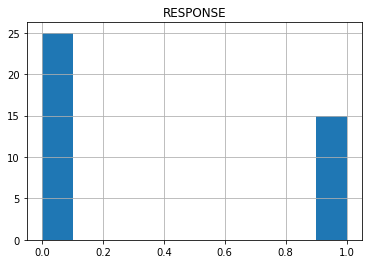

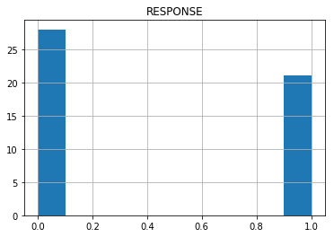

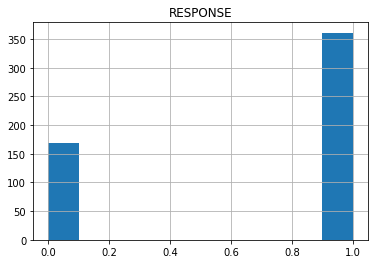

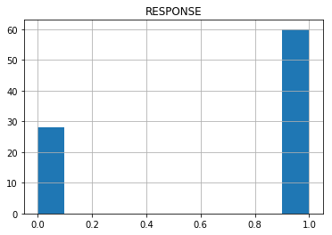

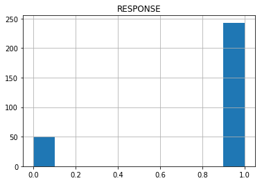

```python
#6.A
df.groupby('HISTORY').hist('RESPONSE')
```

##### We notice as before that surprisingly that someone who is historically worse at paying back their loans actually paid back this loan more often.

```
EMPLOYMENT
0    [[AxesSubplot(0.125,0.125;0.775x0.755)]]
1    [[AxesSubplot(0.125,0.125;0.775x0.755)]]
2    [[AxesSubplot(0.125,0.125;0.775x0.755)]]
3    [[AxesSubplot(0.125,0.125;0.775x0.755)]]
4    [[AxesSubplot(0.125,0.125;0.775x0.755)]]
dtype: object
```

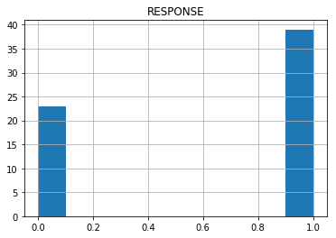

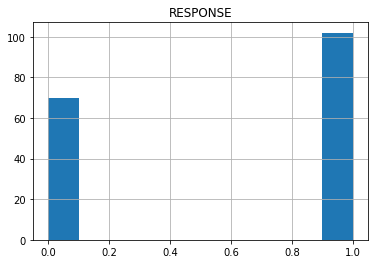

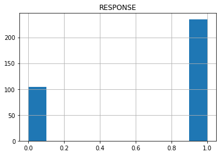

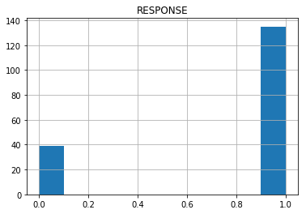

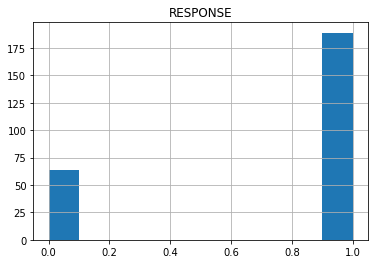

```python
#6.B

df.groupby('EMPLOYMENT').hist('RESPONSE')
```

##### Again as previously discussed, it seems that there is a clear relationship between length of employment and liklihood to repay loans

```
JOB
0    [[AxesSubplot(0.125,0.125;0.775x0.755)]]
1    [[AxesSubplot(0.125,0.125;0.775x0.755)]]
2    [[AxesSubplot(0.125,0.125;0.775x0.755)]]
3    [[AxesSubplot(0.125,0.125;0.775x0.755)]]
dtype: object
```

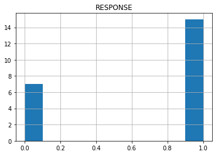

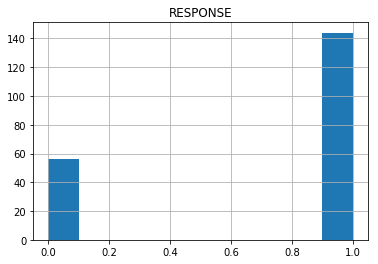

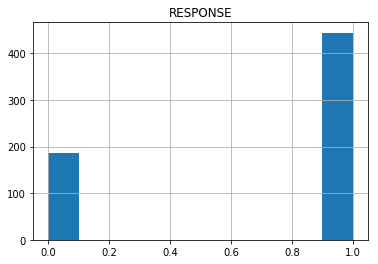

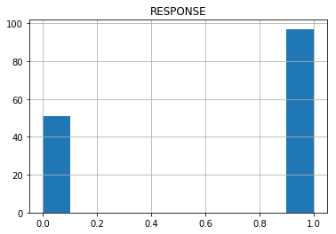

```python
#6.C

df.groupby('JOB').hist('RESPONSE')
```

# Question 7

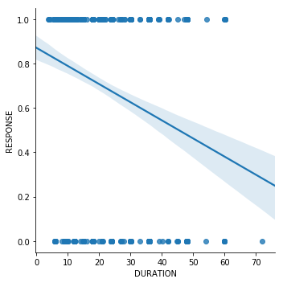

```python
sns.lmplot("DURATION", "RESPONSE", df, x_jitter = .15)
```

##### This is a linear plot that shows the relationship between the duration that someone has had the loan outstanding, and if they paid the loan back or not. We can see a clear negative relationship between duration and response, meaning that the longer someone has a loan outstanding, the less likely they are to pay the loan back.

# Question 8

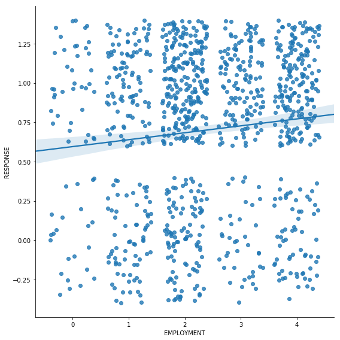

```python
#Linear regression plot
sns.lmplot("EMPLOYMENT", "RESPONSE", df, y_jitter=0.40, x_jitter=.40, size=8)
```

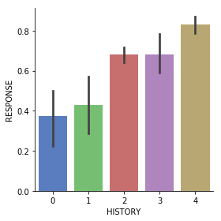

```python
#Factor Plot
sns.factorplot("HISTORY", "RESPONSE", data=df, kind='bar', palette='muted')
```

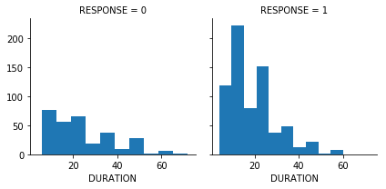

```python
#Face Grid
g = sns.FacetGrid(df, col="RESPONSE")
g.map(plt.hist, "DURATION")
```

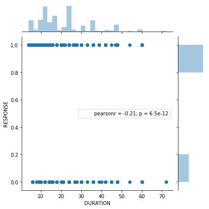

```python
#Joint Plot

sns.jointplot("DURATION", "RESPONSE", df)
```

##### From our analysis, we can gather the following:

[output not shown]

# Question 9

```python
#how many people were in each class
count = df.groupby('HISTORY').count()

#how many people were in each class in terms of the RESPONSE column only
response_count = df.groupby('HISTORY').RESPONSE.count()

#How many actually repaid the loan
response_sum = df.groupby('HISTORY').RESPONSE.sum()
```

```python
response_prob = response_sum / response_count
print response_prob
```

```
HISTORY
0    0.375000
1    0.428571
2    0.681132
3    0.681818
4    0.829352
Name: RESPONSE, dtype: float64
```

```
Text(0.5,1,'Number of people per Credit History Class')
```

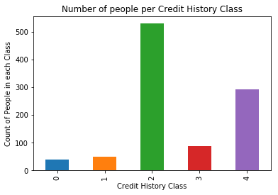

```python
response_count.plot(kind='bar')
plt.xlabel('Credit History Class')
plt.ylabel('Count of People in each Class')
plt.title("Number of people per Credit History Class")
```

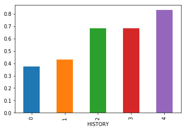

```python
response_prob.plot(kind='bar')
```

##### We can see that the longer someone has an established history of credit, the more likely they are to repay the loan.

# Question 10: Create your own questions.

```
Does install rate have an effect on response?
```

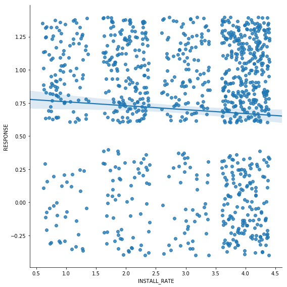

```python
sns.lmplot("INSTALL_RATE", "RESPONSE", df, y_jitter=0.40, x_jitter=.40, size=8)
```

##### Install rate seems to have a slightly negative correlation with response, meaning that as the install rate increases, the liklihood that someone repays the loan decreases.

# Question 11: Create your own questions.

```
Does the number of dependents the borrower has have an impact on repsonse?
```

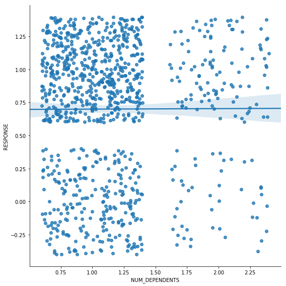

```python
sns.lmplot("NUM_DEPENDENTS", "RESPONSE", df, y_jitter=0.40, x_jitter=.40, size=8)
```

##### Based on the above plot, the number of dependents a person has does not impact wether or not someone will repay their loan.

# Question 12

### On my honor, as a student, I have neither given nor received unauthorized aid on this academic work.